# N170 from ERP-fix

Hannah, 9/12/2017

**Total sample is 65 subjects** *Changed to cross-classified models (not electrode nested within subject)*

### 1. N170 grand averages

**Negative is plotted downwards.**

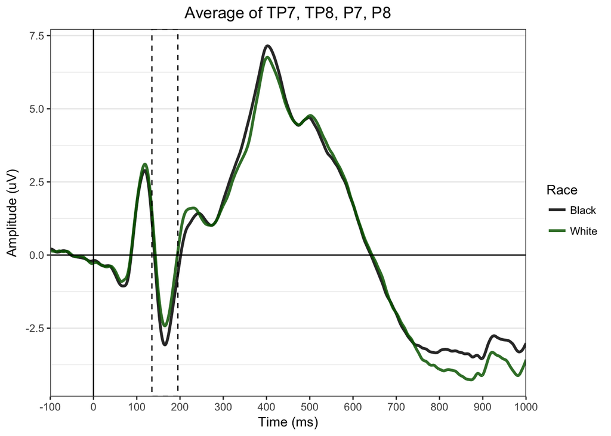

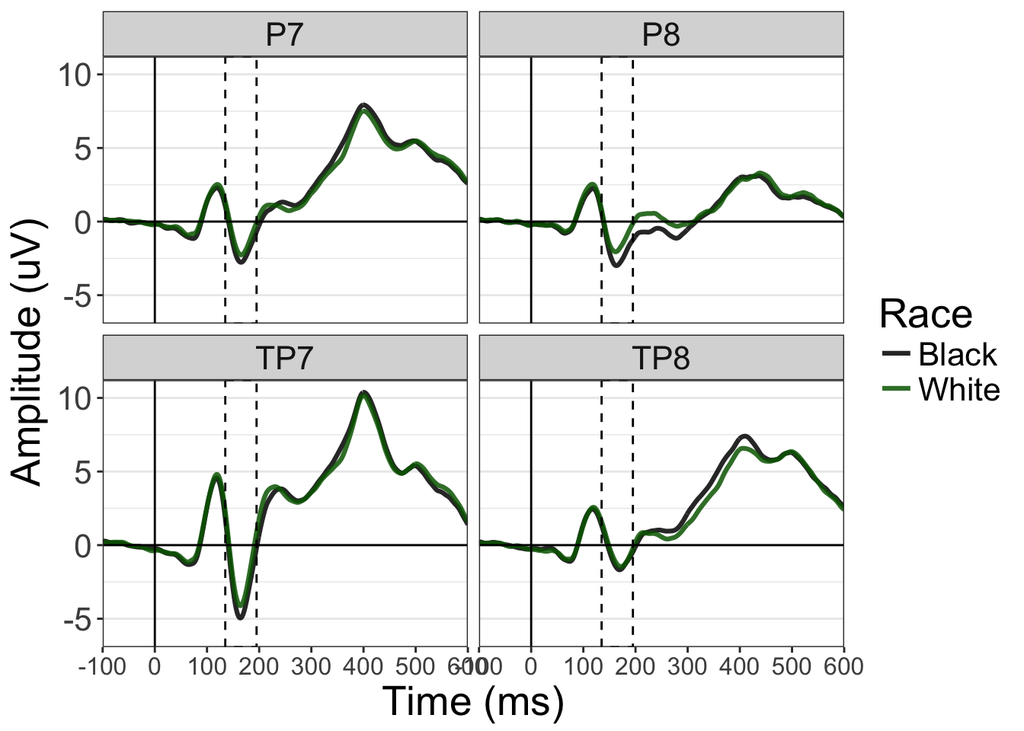

#### Signal averaging approach:

All trials were averaged together and the mean amplitude was calculated for each condition for each subject. Subject and electrode were used as crossed random factors. ICCs were first calculated with an intercept-only model.

```
## summary from lme4 is returned
## some computational error has occurred in lmerTest
```

```
## Linear mixed model fit by REML ['lmerMod']
## Formula: MeanAmp ~ (1 | Subject) + (1 | Electrode)
##    Data: sigavg
##
## REML criterion at convergence: 2234.9
##
## Scaled residuals:
##     Min      1Q  Median      3Q     Max
## -3.4867 -0.5670  0.0173  0.6396  2.6165
##
## Random effects:
##  Groups    Name        Variance Std.Dev.
##  Subject   (Intercept) 4.8994   2.2135
##  Electrode (Intercept) 0.3832   0.6191
##  Residual              3.0517   1.7469
## Number of obs: 520, groups:  Subject, 65; Electrode, 4
##
## Fixed effects:
##             Estimate Std. Error t value
## (Intercept)  -1.3232     0.4208  -3.145
```

The ICC associated with *subject* is 0.5878598.  
The ICC associated with *electrode* is 0.0459787.

A model was fitted with Race predicting mean amplitude calculated in this way. The intercept and slope of Race were allowed to vary by subject. The intercept was allowed to vary by Electrode.

Race was effect coded.

**Random effects:**

```
##  Groups    Name        Std.Dev. Corr
##  Subject   (Intercept) 2.2218
##            Race.e      0.4560   -0.251
##  Electrode (Intercept) 0.6209
##  Residual              1.6603
```

**Fixed effects:**

```
##             Estimate Std. Error     df t value Pr(>|t|)
## (Intercept)   -1.323      0.421  8.889  -3.140    0.012
## Race.e         0.239      0.092 64.000   2.593    0.012
```

### 2. Looking at the N170 over the course of the experiment

ICCs were first calculated for subject and electrode.

```
## summary from lme4 is returned
## some computational error has occurred in lmerTest
```

```
## Linear mixed model fit by REML ['lmerMod']
## Formula: MeanAmp ~ (1 | Subject) + (1 | Electrode)
##    Data: dat
##
## REML criterion at convergence: 374021.1
##
## Scaled residuals:
##     Min      1Q  Median      3Q     Max
## -4.8531 -0.6289 -0.0007  0.6293  6.0677
##
## Random effects:
##  Groups    Name        Variance Std.Dev.
##  Subject   (Intercept)   5.1535  2.2701
##  Electrode (Intercept)   0.4853  0.6966
##  Residual              101.8823 10.0937
## Number of obs: 50092, groups:  Subject, 65; Electrode, 4
##
## Fixed effects:
##             Estimate Std. Error t value
## (Intercept)  -1.3175     0.4503  -2.926
```

The ICC associated with *subject* is 0.0479301.  
The ICC associated with *electrode* is 0.0045135.

**Slopes and estimates of lines are from the MLM, not fitted with OLS. Negative is plotted downward.**

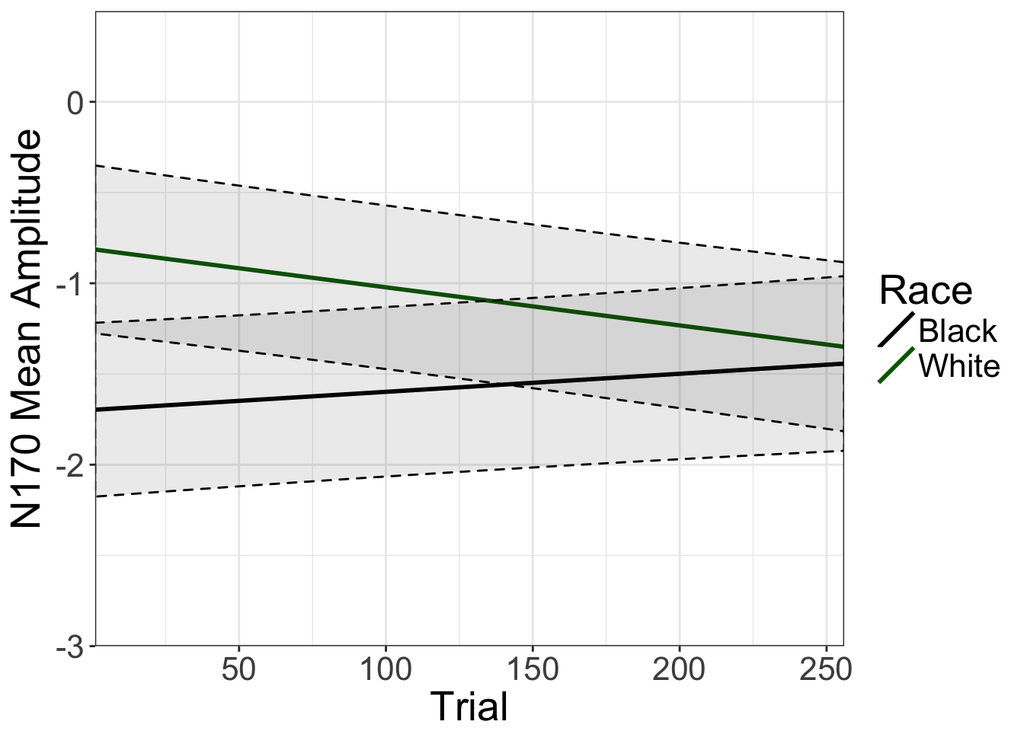

##### Simple slopes

Trial is scaled to range from 0 to 10 (instead of 1 to 256) so that the betas associated with trial are a little bigger (but significance testing is unaffected by linear scaling, so the test statistics and p values will be the same as if we used the unscaled Trial variable).

```
##   Estimate     SE ci95_lower ci95_upper  Race
## 1   0.0255 0.0226    -0.0198    0.07076 Black
## 2  -0.0536 0.0225    -0.0987   -0.00859 White
```

#### Model output: Beginning of experiment

Trial is scaled to range from 0 to 10.

**Random effects:**

```
##  Groups    Name        Std.Dev. Corr
##  Subject   (Intercept)  2.27150
##            Race.e       0.59304 -0.178
##  Electrode (Intercept)  0.69666
##  Residual              10.07395
```

**Fixed effects:**

```
##                    Estimate Std. Error        df t value Pr(>|t|)
## (Intercept)          -1.255      0.457     8.411  -2.748    0.024
## Race.e                0.442      0.115   181.207   3.829    0.000
## Trial.begin          -0.014      0.016 50051.657  -0.881    0.379
## Race.e:Trial.begin   -0.040      0.016 49122.824  -2.481    0.013
```

#### Model output: End of experiment

**Random effects:**

```
##  Groups    Name        Std.Dev. Corr
##  Subject   (Intercept)  2.27149
##            Race.e       0.59304 -0.178
##  Electrode (Intercept)  0.69666
##  Residual              10.07395
```

**Fixed effects:**

```
##                  Estimate Std. Error        df t value Pr(>|t|)
## (Intercept)        -1.396      0.458     8.515  -3.047    0.015
## Race.e              0.046      0.120   209.856   0.382    0.703
## Trial.end          -0.014      0.016 50051.211  -0.881    0.379
## Race.e:Trial.end   -0.040      0.016 49122.398  -2.481    0.013
```

### 3. Testing variances of slopes and intercepts using log likelihood tests

```
## refitting model(s) with ML (instead of REML)
```

```
## Data: dat
## Models:
## ..1: MeanAmp ~ Race.d * Trial.begin
## object: MeanAmp ~ Race.d * Trial.begin + (1 | Subject)
##        Df    AIC    BIC  logLik deviance  Chisq Chi Df Pr(>Chisq)
## ..1     5 376432 376476 -188211   376422
## object  6 374156 374209 -187072   374144 2278.3      1  < 2.2e-16 ***
## ---
## Signif. codes:  0 '***' 0.001 '**' 0.01 '*' 0.05 '.' 0.1 ' ' 1
```

```
## refitting model(s) with ML (instead of REML)
```

```
## Data: dat
## Models:
## object: MeanAmp ~ Race.d * Trial.begin + (1 | Subject)
## ..1: MeanAmp ~ Race.d * Trial.begin + (Race.d | Subject)
##        Df    AIC    BIC  logLik deviance  Chisq Chi Df Pr(>Chisq)
## object  6 374156 374209 -187072   374144
## ..1     8 374087 374157 -187035   374071 72.932      2  < 2.2e-16 ***
## ---
## Signif. codes:  0 '***' 0.001 '**' 0.01 '*' 0.05 '.' 0.1 ' ' 1
```

```
## refitting model(s) with ML (instead of REML)
```

```
## Data: dat
## Models:
## ..1: MeanAmp ~ Race.d * Trial.begin
## object: MeanAmp ~ Race.d * Trial.begin + (1 | Electrode)
##        Df    AIC    BIC  logLik deviance Chisq Chi Df Pr(>Chisq)
## ..1     5 376432 376476 -188211   376422
## object  6 376280 376333 -188134   376268 153.8      1  < 2.2e-16 ***
## ---
## Signif. codes:  0 '***' 0.001 '**' 0.01 '*' 0.05 '.' 0.1 ' ' 1
```